# Project

Topi Sirkiä, Touko Puro, William McWhorter

12/4/2021

Let’s read in the data and remove columns 1,2,4 (id,date,partlybad) which are unhelpful.

```r
npf <- read.csv("npf_train.csv") #read in data
npf_test <- read.csv("npf_test_hidden.csv")

npf <- npf[,-c(1:2,4)] # drop the id, date, partlybad columns
npf_test <- npf_test[,-c(1:2,4)]
print(npf)
```

```
##       class4 CO2168.mean  CO2168.std CO2336.mean  CO2336.std CO242.mean
## 1   nonevent    384.4620  2.28499603    384.1645  2.13506223   385.2747
## 2   nonevent    374.8846  0.41518480    374.7033  0.38517888   375.6213
## 3   nonevent    373.4966  0.18949719    373.3826  0.17295793   373.9615
## 4   nonevent    378.6004  1.93417986    378.4649  1.94653615   379.7859
## 5         Ib    373.1287  1.09661712    372.9800  1.04775010   373.7018
## 6         II    375.1434  1.34299881    374.8048  1.00995910   375.6478
## 7         II    373.9728  1.12077140    373.8644  1.08174726   374.9731
## 8         Ib    376.0066  1.10978867    375.8889  1.05215658   376.7799
## 9   nonevent    381.9571  3.51854048    382.0971  3.61947632   382.2798
## 10        Ia    373.2621  0.91585237    373.2996  0.84283422   373.5794
## 11        II    374.3245  2.16983628    374.3694  2.12119350   374.6002
## 12        Ib    369.1932  4.19445061    369.1189  3.72353392   369.4396
## 13        Ib    368.5694  1.90732599    368.7061  1.76957260   368.8798
## 14        II    370.4237  3.22319698    370.3894  2.94482829   370.7377
```

[output cut: 7788 more lines]

Let’s further restrict the case to binary classification by classifying Ib,Ia and II event types as just “event”. We can also drop class 4 column afterwards.

```r
npf$class2 <- factor("event",levels=c("nonevent", "event"))
npf$class2[npf$class4=="nonevent"] <- "nonevent"
npf <- npf[,-1]
```

Lets try to do some variable selection using repeated 10 fold cv with caret’s trainControl function and selecting variables with the varImp() function. As our method for now we will have linear svm. It turns out a bit later that its not a good idea to start variable selection before cutting the highly correlated stuff out but we fix it later.

```r
set.seed(7)

# lets use caret
library(caret)
```

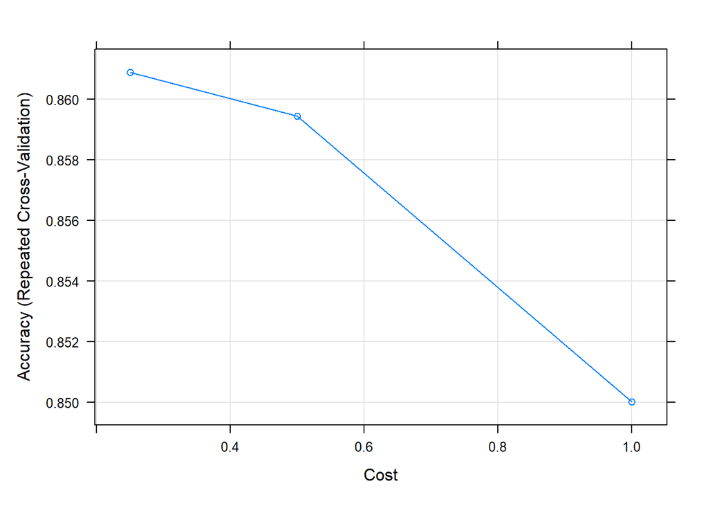

```r
#note that classprobs argument has to be true if we want svm to give probabilities
control <- trainControl(method="repeatedcv", number=10, repeats=3,classProbs=TRUE)
model <- train(class2~., data=npf, method="svmLinear2", preProcess="scale", trControl=control)

#lets sort the importances
importance <- data.frame(varImp(model, scale=FALSE)$importance)
importance <- data.frame(importance, names = rownames(importance))
importance <- importance[order(importance$event,decreasing = T),]

plot(model)
```

One can try different folds (number) and repetitions (repeats) in the trainControl function to see what happens. These current values I just threw in.

Let’s plot the importances:

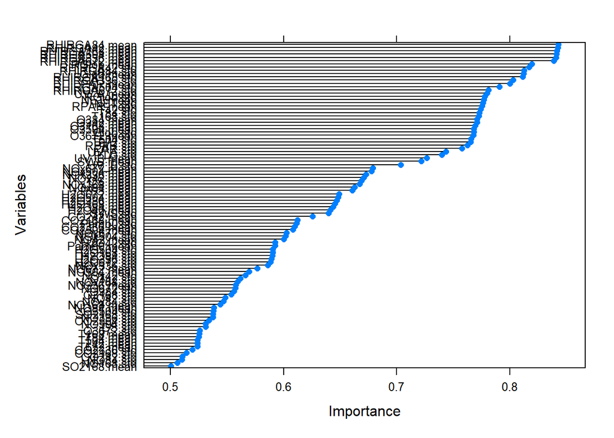

```r
plot(varImp(model, scale=FALSE), ylab="Variables")
```

Ignoring the messy y axis names, we can see how the importance changes. It’s clear that that there is a large dropoff in variable importance around importance=0.76 so that could be a good cut off point. However this may still be too many features. Other options include simply taking the very top features (Those are the RHIRGA values) around importance=0.85 or somewhere in the middle of these two, around importance=80.

```r
print(importance)
```

```
##                 nonevent     event          names
## RHIRGA84.mean  0.8427948 0.8427948  RHIRGA84.mean
## RHIRGA42.mean  0.8423752 0.8423752  RHIRGA42.mean
## RHIRGA168.mean 0.8414790 0.8414790 RHIRGA168.mean
## RHIRGA504.mean 0.8412120 0.8412120 RHIRGA504.mean
## RHIRGA336.mean 0.8409641 0.8409641 RHIRGA336.mean
## RHIRGA672.mean 0.8388475 0.8388475 RHIRGA672.mean
## RGlob.mean     0.8194161 0.8194161     RGlob.mean
## RHIRGA42.std   0.8168609 0.8168609   RHIRGA42.std
## RHIRGA84.std   0.8126275 0.8126275   RHIRGA84.std
## Glob.mean      0.8121889 0.8121889      Glob.mean
## RHIRGA168.std  0.8114643 0.8114643  RHIRGA168.std
## RHIRGA336.std  0.8026735 0.8026735  RHIRGA336.std
## PAR.mean       0.7999275 0.7999275       PAR.mean
## RHIRGA504.std  0.7908697 0.7908697  RHIRGA504.std
## RHIRGA672.std  0.7810873 0.7810873  RHIRGA672.std
## UV_A.mean      0.7797143 0.7797143      UV_A.mean
## RGlob.std      0.7778074 0.7778074      RGlob.std
## NET.mean       0.7771782 0.7771782       NET.mean
## NET.std        0.7760722 0.7760722        NET.std
## RPAR.mean      0.7752713 0.7752713      RPAR.mean
## T42.std        0.7740508 0.7740508        T42.std
## T84.std        0.7727732 0.7727732        T84.std
## T168.std       0.7726969 0.7726969       T168.std
## O342.mean      0.7708472 0.7708472      O342.mean
## O384.mean      0.7708472 0.7708472      O384.mean
## O3168.mean     0.7694743 0.7694743     O3168.mean
## O3504.mean     0.7681585 0.7681585     O3504.mean
## Glob.std       0.7681013 0.7681013       Glob.std
## O3672.mean     0.7676055 0.7676055     O3672.mean
## T504.std       0.7656223 0.7656223       T504.std
## T672.std       0.7651837 0.7651837       T672.std
## RPAR.std       0.7624759 0.7624759       RPAR.std
## PAR.std        0.7576133 0.7576133        PAR.std
## UV_A.std       0.7435785 0.7435785       UV_A.std
## PTG.std        0.7398696 0.7398696        PTG.std
## UV_B.mean      0.7265689 0.7265689      UV_B.mean
## SWS.mean       0.7217254 0.7217254       SWS.mean
## UV_B.std       0.7036288 0.7036288       UV_B.std
## NOx672.mean    0.6788772 0.6788772    NOx672.mean
```

[output cut: 46 more lines]

```
## CO2504.std     0.5338190 0.5338190     CO2504.std
## NO504.std      0.5312256 0.5312256      NO504.std
## CS.std         0.5309395 0.5309395         CS.std
## O3672.std      0.5256574 0.5256574      O3672.std
## T168.mean      0.5253523 0.5253523      T168.mean
## T84.mean       0.5251807 0.5251807       T84.mean
## T504.mean      0.5239793 0.5239793      T504.mean
## T42.mean       0.5238077 0.5238077       T42.mean
## T672.mean      0.5237124 0.5237124      T672.mean
## CO2336.std     0.5192121 0.5192121     CO2336.std
## CO2168.std     0.5140634 0.5140634     CO2168.std
## CO242.std      0.5106119 0.5106119      CO242.std
## NO84.std       0.5099064 0.5099064       NO84.std
## NO168.std      0.5060163 0.5060163      NO168.std
## SO2168.mean    0.5004291 0.5004291    SO2168.mean
```

Lets create new data sets for each of the aforementioned cutoffs.

```r
npf <- npf[,c(ncol(npf),1:(ncol(npf)-1))] #move class2 column to first

npf75names <- importance[importance["event"]>0.75,]$names #33 features
npf82names <- importance[importance["event"]>0.80,]$names # 12
npf83_8names <- importance[importance["event"]>0.838,]$names #6

npf75 <- npf[, c("class2",npf75names)]
npf82 <- npf[, c("class2",npf82names)]
npf83_8 <- npf[, c("class2",npf83_8names)]
```

We are now ready to compare. The features obtained here are only good for working with the chosen model. If we want to try another model, we have to do the variable selection over, since different models may rely on different features. For this reason we may want to make a function that takes in the wanted model name and does all the above for us, but I didnt do that yet.

Now that we have 3 sets of possible features, we can train the model again for each of them, and see which has the best CV-score. That will be the model we go with.

```r
model1 <- train(class2~., data=npf75, method="svmLinear2", preProcess="scale", trControl=control)
model2 <- train(class2~., data=npf82, method="svmLinear2", preProcess="scale", trControl=control)
model3 <- train(class2~., data=npf83_8, method="svmLinear2", preProcess="scale", trControl=control)
```

```r
library(knitr)

df <- setNames(data.frame(matrix(ncol = 4, nrow = 3)), names(model1$results)[2:5])
rownames(df) <- c("npf75", "npf82", "npf83_8")

df[1,] = sapply(model1$results, mean)[2:5] #mean is over the 3 repetitions of the 10 fold cv.
df[2,] = sapply(model2$results, mean)[2:5]
df[3,] = sapply(model3$results, mean)[2:5]
kable(df)
```

|  | Accuracy | Kappa | AccuracySD | KappaSD |
| --- | --- | --- | --- | --- |
| npf75 | 0.8264520 | 0.6527629 | 0.0498729 | 0.0999670 |
| npf82 | 0.8052330 | 0.6104905 | 0.0456542 | 0.0913369 |
| npf83_8 | 0.7903382 | 0.5806065 | 0.0654724 | 0.1309128 |

The cv accuracy seems to go down when we decrease the amount of features. Currently we have a lot of very correlated features, so that might be the reason. For example near the top we only have each of the RHIRGA’s. It seems that the train() and varImp() functions didnt care about features being correlated.

```r
library(GGally)
```

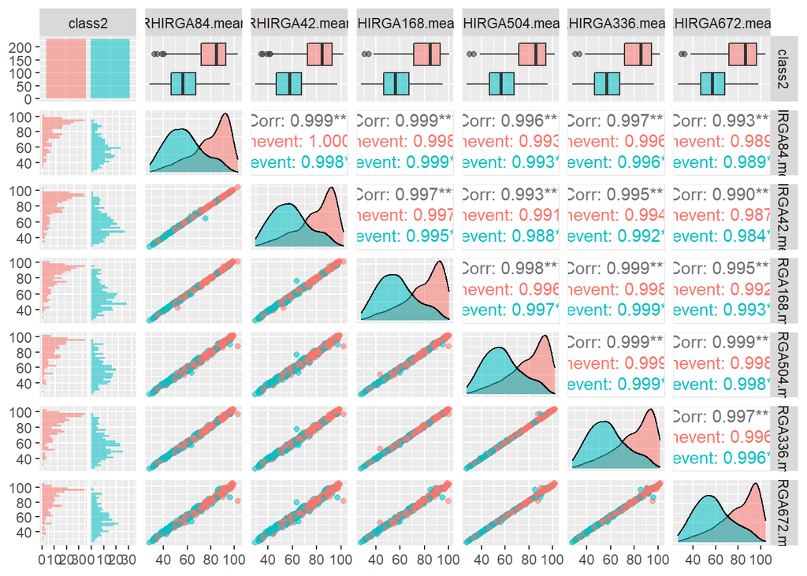

```r
ggpairs(npf83_8, aes(colour = class2, alpha = 0.4))
```

I suppose before choosing features, we should toss out all the very correlated stuff. This can be done by making a correlation matrix using the cor() function and then using the caret findCorrelation() function which will give the indices of the columns that are highly correlated. Then we drop those columns and hopefully get a more sensible result. Lets consider the original dataframe npf.

```r
cm <- cor(npf[,-1]) # note that we ignore the class 2 column here as we dont want to drop it obviously

# find attributes that are highly corrected (the threshold for being cut can be changed.)
highcorr <- findCorrelation(cm, cutoff = 0.75)+1 #+1 to get the indexing in the npf df where class2 bumps all the indices up by 1.

print(highcorr) # indices of what we want to cut
```

```
##  [1]  7  8 11 12 14 15 16 18 19 20 21 22 24 25 28 30 32 33 34 36 37 38 40 42 44
## [26] 46 47 48 49 53 54 56 58 59 62 63 67 68 70 72 73 74 76 78 79 81 86 87 88 89
## [51] 90 92 93 94 95 96 97 98 99  2  3  4  5 13 17 26 29 50 51 55 10 69 71 75 66
```

```r
npf <- npf[,-c(highcorr)]
print(npf)
```

```
##       class2 CO242.mean  CO2504.std  H2O84.std  NO168.std   NO42.std  NO672.std
## 1   nonevent   385.2747  1.95519830 0.05368097 0.07122655 0.04730432 0.05520155
## 2   nonevent   375.6213  0.43547972 0.13361270 0.12928561 0.10648069 0.19332407
## 3   nonevent   373.9615  0.16550018 0.25764367 0.02839080 0.03114532 0.03177370
## 4   nonevent   379.7859  1.98343033 0.07274799 0.23592153 0.18542927 0.20765902
## 5      event   373.7018  1.00416370 0.29811916 0.04030594 0.04537938 0.04289430
## 6      event   375.6478  0.83447144 0.27200431 0.10707254 0.09147747 0.07569889
## 7      event   374.9731  1.04124774 0.18791671 0.05279074 0.04311852 0.04600441
## 8      event   376.7799  0.96035167 0.43407580 0.07435208 0.05398085 0.06747003
## 9   nonevent   382.2798  3.68696519 1.93851065 0.13481724 0.08308813 0.12073571
## 10     event   373.5794  0.81164991 0.36680226 0.04749298 0.04570071 0.04338242
## 11     event   374.6002  2.02700237 1.27735559 0.09656541 0.05679848 0.05195316
## 12     event   369.4396  2.55189891 0.79127116 0.06024830 0.05548443 0.05585528
## 13     event   368.8798  1.65675579 0.28369325 0.04929261 0.05403346 0.04914501
## 14     event   370.7377  2.61870837 0.56059433 0.05762274 0.04763083 0.05387493
```

[output cut: 2280 more lines]

We are left with 26 columns, and they look a lot more varied now. Lets find the importances.

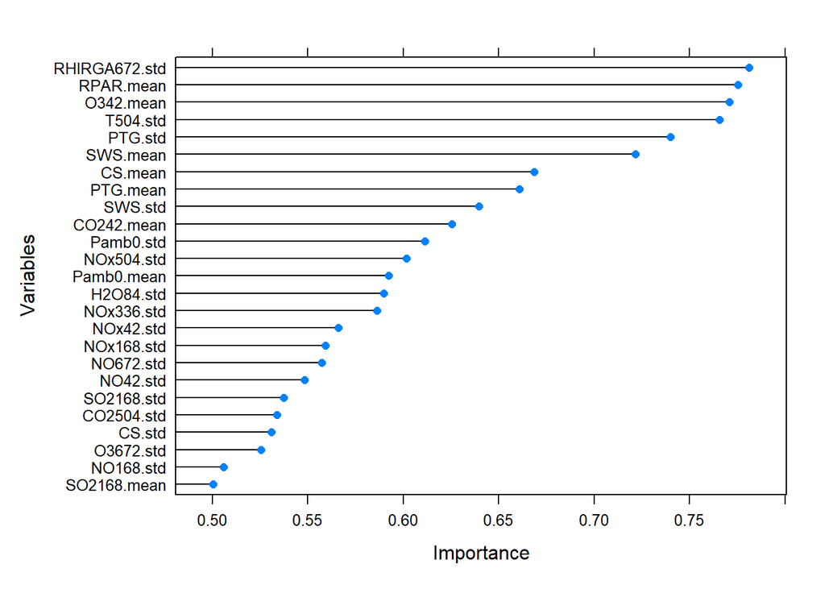

```r
control <- trainControl(method="repeatedcv", number=10, repeats=3,classProbs=TRUE)
model <- train(class2~., data=npf, method="svmLinear2", preProcess="scale", trControl=control)

plot(varImp(model, scale=FALSE), ylab="Variables")
```

This looks better. Let’s pick for example the variables with importance above 70 (above 75 is another choice). Lets also check the pair plot now.

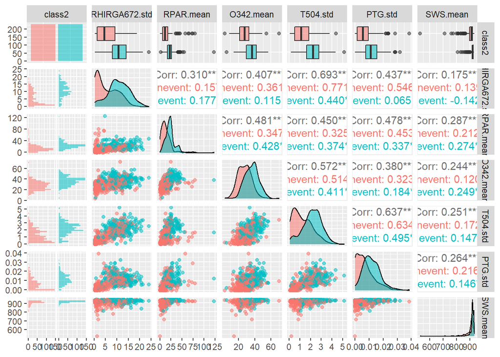

```r
#lets sort the importances
importance <- data.frame(varImp(model, scale=FALSE)$importance)
importance <- data.frame(importance, names = rownames(importance))
importance <- importance[order(importance$event,decreasing = T),]

npf70names <- importance[importance["event"]>0.70,]$names #6 features
npf75names <- importance[importance["event"]>0.75,]$names # 4 features


npf70 <- npf[, c("class2",npf70names)]
npf75 <- npf[, c("class2",npf75names)]

ggpairs(npf70, aes(colour = class2, alpha = 0.4))
```

Ok, looks better. Now lets train a model for both cases:

```r
model1 <- train(class2~., data=npf70, method="svmLinear2", preProcess="scale", trControl=control)
model2 <- train(class2~., data=npf75, method="svmLinear2", preProcess="scale", trControl=control)


df <- setNames(data.frame(matrix(ncol = 4, nrow = 2)), names(model1$results)[2:5])
rownames(df) <- c("npf70", "npf75")

df[1,] = sapply(model1$results, mean)[2:5] #mean is over the 3 repetitions of the 10 fold cv.
df[2,] = sapply(model2$results, mean)[2:5]

kable(df)
```

|  | Accuracy | Kappa | AccuracySD | KappaSD |
| --- | --- | --- | --- | --- |
| npf70 | 0.7662319 | 0.5324533 | 0.0526347 | 0.1052767 |
| npf75 | 0.7730542 | 0.5463325 | 0.0658601 | 0.1316146 |

```r
npf_test <- npf_test[,c(ncol(npf_test),1:(ncol(npf_test)-1))] #move class2 column to first

predictions <- predict(model1, npf_test)
npf_test$class2 <- predictions # If we need to estimate something for the multiclass probabilities, I guess the best we could do with the binary probabilities is to look at the frequencies of each class [ia,ib,ii] in the original dataset and then split the "event" probability accordingly into those class probabilities

table(predictions)
```

```
## predictions
## nonevent    event
##      436      529
```

```r
head(npf_test)
```

```
##         CS.std class4 CO2168.mean CO2168.std CO2336.mean CO2336.std CO242.mean
## 1 0.0001186413     NA    376.6102  0.5266173    376.6603  0.5002033   376.9347
## 2 0.0001152320     NA    390.6249  0.4535849    390.5807  0.4553077   391.0007
## 3 0.0004275496     NA    375.2803  1.2490869    375.4798  1.2415248   375.6241
## 4 0.0005100730     NA    382.6422  3.2228049    382.8904  3.0261404   383.1369
## 5 0.0044375423     NA    381.4930  4.3869286    381.6080  4.3335582   382.1778
## 6 0.0004034571     NA    386.2436  2.7019081    386.5380  2.6930577   386.1383
##   CO242.std CO2504.mean CO2504.std Glob.mean  Glob.std H2O168.mean H2O168.std
## 1 0.5643603    376.6347  0.4712359  37.11559  24.18079    4.357458 0.09784917
## 2 0.5058363    390.4879  0.4812915  69.13453  59.89506    1.198630 0.03845326
## 3 1.4235062    375.5715  1.2005557 276.48537 201.72267    4.560452 0.53822742
## 4 3.4662592    382.9377  2.8375404 308.90430 287.44465    5.962471 0.69441543
## 5 4.4918752    381.5889  4.2632994 111.45688 104.80701   12.808000 2.26585271
## 6 3.0181090    386.5771  2.5557368 310.21017 236.44283    4.025172 0.29820605
##   H2O336.mean H2O336.std H2O42.mean  H2O42.std H2O504.mean H2O504.std
```

[output cut: 97 more lines]

Lets take a look at the predicted probabilities

```r
predictedprobs <- predict(model1, npf_test, type="prob")
print(predictedprobs)
```

```
##       nonevent        event
## 1   0.75773702 0.2422629766
## 2   0.81930094 0.1806990555
## 3   0.18113728 0.8188627152
## 4   0.03556987 0.9644301258
## 5   0.59405169 0.4059483084
## 6   0.28298405 0.7170159511
## 7   0.95483014 0.0451698618
## 8   0.92405998 0.0759400243
## 9   0.15953492 0.8404650789
## 10  0.11583527 0.8841647331
## 11  0.73936939 0.2606306053
## 12  0.60719848 0.3928015209
## 13  0.71942929 0.2805707053
## 14  0.80517781 0.1948221929
```

[output cut: 951 more lines]

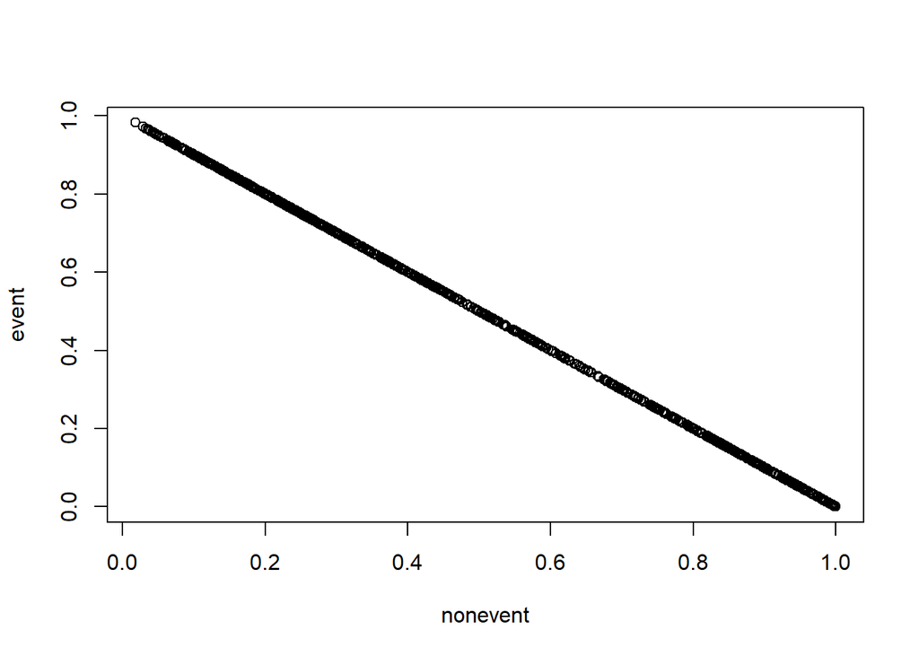

```r
plot(predictedprobs)
```

parameters that can be changed: -number of kfolds/repetitions (currently 10/3) -the model itself (random forest maybe next) -number of features included (although for this model these seem the best) -cut-off rate for the correlations (currently 0.75)

Let’s try to generalize the above with a function that does all of it for a given model. Note that the with the svm the cutoffs were manually chosen by looking at the plot. Within the function theres no way to really look at the plot and make the cutoffs for each model.